# Perceptron

This notebook details my steps in creating my own perceptron algorithm from scratch. Data was supplied by Professor Cliff Baldwin.

Obviously, the first thing is to read in the data we have. There were two data sets supplied: a clean one and a not-so-clean one. I will be working with the clean data set to work on the algorithm and then after I will see how it fares on the “drity” data set. To clarify: the clean dataset is one that this should work on with near to no error. The “dirty” one is one that may need a little tweaking in the algorithm to do.

```r
data = read.csv("CleanData.csv", header = TRUE) # Clean data set
head(data)                                      # Check the first six lines
```

|  | X1 | X2 | Y |
| --- | --- | --- | --- |
| 1 | -0.3569816 | 0.2575486 | 1 |
| 2 | 0.4378550 | 0.5839710 | 1 |
| 3 | -0.4182532 | -0.4897950 | 1 |
| 4 | 0.8645396 | -0.6638159 | -1 |
| 5 | 0.5382939 | -0.5122558 | -1 |
| 6 | 0.2889823 | 0.5232478 | 1 |

```r
tail(data)                                      # Check the last six lines
```

|  | X1 | X2 | Y |
| --- | --- | --- | --- |
| 995 | -0.80670274 | -0.7251476 | 1 |
| 996 | -0.01256357 | 0.8664105 | 1 |
| 997 | -0.34666920 | 0.6982815 | 1 |
| 998 | -0.98480139 | 0.4395301 | 1 |
| 999 | 0.01874018 | -0.8517361 | -1 |
| 1000 | -0.02594179 | -0.4639846 | 1 |

```r
head(data)
```

|  | X1 | X2 | Y |
| --- | --- | --- | --- |
| 1 | -0.3569816 | 0.2575486 | 1 |
| 2 | 0.4378550 | 0.5839710 | 1 |
| 3 | -0.4182532 | -0.4897950 | 1 |
| 4 | 0.8645396 | -0.6638159 | -1 |
| 5 | 0.5382939 | -0.5122558 | -1 |
| 6 | 0.2889823 | 0.5232478 | 1 |

Great. Now that that is working, it is time to work on the algorithm.

```r
perceptron <- function(data) {
  # This function takes an imput of "data" which should be two columns of values along with a third collumn of "answers" and a fourth collumn of "guesses." Throughout this function, the algorithm will attempt to make its guesses the same as the answers.

  # ==============================================================================================================

  # Test Data

  # --------------------------------------------------------------------------------------------------------------

  # Read in the test data
  # We take a random sample from the data to train the algorithm. Since there are 1000 observations, we will take a random 250.
  whole_test_data   <- data[sample(nrow(data), 0.25 * nrow(data)), ]                         # Take a random 25% of the rows from the data set.
  whole_test_data$g <- c(1)                                                                  # The initial guesses
  test_data         <- data.frame(whole_test_data$X1, whole_test_data$X2, whole_test_data$g) # Test data with no answers
  true_ans          <- c(data$Y)                                                             # The answers for the whole dataset
  answers           <- c(whole_test_data$Y)                                                  # Answers to the test data

  # --------------------------------------------------------------------------------------------------------------

  # Testing the Test data
  # We have to assign weights to each column in order to make this work the way we want to. Initially, we will begin with each weight being zero.
  w        <- c(0,0,0)   # vector of the weights
  classify <- c()        # Empty vector to store the guesses
  all_classified = FALSE # Does classified = answers? If this is true, the loop will break
  # Now for the loop
  while ( !all_classified ) {
    for ( i in 1:nrow(test_data) ) {                            # iterate over all rows in the test data
      classify[i] <- as.integer(sign(sum(test_data[i,] * w)))   # first guess
      if (sign(classify[i]) != sign(answers[i])) {              # loop to change the weights depending if the guess is wrong
        w[1] = w[1] + test_data[i,1] * answers[i]               # weight for X1
        w[2] = w[2] + test_data[i,2] * answers[i]               # weight for X2
        w[3] = w[3] + test_data[i,3] * answers[i]               # weight for X3
      }
    }
    if ( identical(classify, answers) ) {all_classified = TRUE} # if classified = answers, the loop breaks
  }

  # Now that the algorithm has been trained, we move on to the real data.

  # ==============================================================================================================

  # Real Data

  # --------------------------------------------------------------------------------------------------------------

  # Now that the weights have been properly calibrated, let's see how it stands against the rest of the dataset
  guess <- c() # Empty vector to store the guesses
  error <- c() # Empty vector to store the error readings as true/false
  e     <- 0   # count the number of falses that appear
  for ( i in 1:nrow(data) ) {                        # iterate over the whole dataset
    guess[i] <- as.integer(sign(sum(data[i,] * w)))  # guess each value
    error[i] <- identical(guess[i],true_ans[i])      # give a true/false value for each guess
    if (error[i] == FALSE) {
      e <- e + 1                                     # increment e for each false value
    }
  }
  error_percent <- e/nrow(data) * 100                # the error as a percentage
  message <- c("The error is: ", error_percent, "%") # Print a message that gives the error
  message <- paste(message,collapse = "")

  # ==============================================================================================================

  # Output

  # --------------------------------------------------------------------------------------------------------------

  # The purpose of this particular perceptron algorithm is to return a graph. The data will be plotted on said graph as a scatterplot with a line (hopefully) separating the -1's and the 1's, colored red and blue respectively.

  plot_data <- data.frame(data$X1, data$X2) # Make a new dataframe with which we will graph.
  c    <- data$Y                            # The Y values determine the color.
  c    <- replace(c, c == 1, "blue")        # 1's are blue
  c    <- replace(c, c == -1, "red")        # -1's are red
  plot(plot_data, col = c)                  # Plot
  abline(a = -w[3]/w[2], b = -w[1]/w[2])    # Put in the dividing line. Slope is -w3/w2 and intercept is -w1/w2

  return(message)                           # Print the message

}
```

Now that that has been set up, let’s try it with our clean data.

```
[1] "The error is: 0%"
```

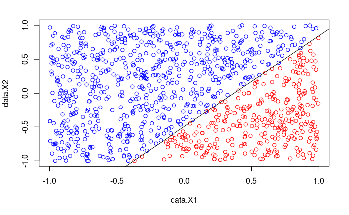

```r
perceptron(data)
```

Now, that worked like a charm! However, that dataset was very clean and nice. That allowed me to get things going. So now, let’s try the same algorithm on a new dataset, this one specifically provided to me by the instructor.

```r
data = read.csv("ClassifyDirtyData_Branco.csv", header = TRUE) # "Dirty"" data set
head(data)                                                     # Check the first six lines
```

|  | X1 | X2 | Y |
| --- | --- | --- | --- |
| 1 | -0.53217232 | 0.06984087 | -1 |
| 2 | -0.77398861 | -0.04883272 | -1 |
| 3 | -0.65699026 | 0.79889304 | 1 |
| 4 | 0.87741146 | -0.30871463 | -1 |
| 5 | -0.05122936 | 0.46497890 | 1 |
| 6 | -0.97166416 | -0.93850250 | -1 |

```r
tail(data)                                                     # Check the last six lines
```

|  | X1 | X2 | Y |
| --- | --- | --- | --- |
| 995 | 0.5805652 | 0.6829267 | 1 |
| 996 | -0.3321118 | -0.8684012 | -1 |
| 997 | 0.3947602 | -0.1251846 | -1 |
| 998 | -0.8571758 | -0.2655022 | -1 |
| 999 | -0.9768518 | 0.6723823 | 1 |
| 1000 | -0.2540947 | -0.2258577 | -1 |

Now, running it with the previous perceptron algorithm caused an infinite loop to occur. This was due to the classify values not matching up one-to-one with the provided answers. To combat this, I will create a new perceptron algorithm that is the same as the one above, but now has a different qualifier for breaking the first loop. Rather than having them be exactly identical, I will have it so that it will break the loop so long as there is less than 5% error.

```r
perceptron <- function(data) {
  # This function takes an imput of "data" which should be two columns of values along with a third collumn of "answers" and a fourth collumn of "guesses." Throughout this function, the algorithm will attempt to make its guesses the same as the answers.

  # ==============================================================================================================

  # Test Data

  # --------------------------------------------------------------------------------------------------------------

  # Read in the test data
  # We take a random sample from the data to train the algorithm. Since there are 1000 observations, we will take a random 250.
  whole_test_data   <- data[sample(nrow(data), 0.25 * nrow(data)), ]                         # Take a random 25% of the rows from the data set.
  whole_test_data$g <- c(1)                                                                  # The initial guesses
  test_data         <- data.frame(whole_test_data$X1, whole_test_data$X2, whole_test_data$g) # Test data with no answers
  true_ans          <- c(data$Y)                                                             # The answers for the whole dataset
  answers           <- c(whole_test_data$Y)                                                  # Answers to the test data

  # --------------------------------------------------------------------------------------------------------------

  # Testing the Test data
  # We have to assign weights to each column in order to make this work the way we want to. Initially, we will begin with each weight being zero.
  w        <- c(0,0,0)   # vector of the weights
  classify <- c()        # Empty vector to store the guesses
  guess <- c() # Empty vector to store the guesses
  error <- c() # Empty vector to store the error readings as true/false
  e     <- 0   # count the number of falses that appear
  all_classified = FALSE # Does classified = answers? If this is true, the loop will break
  # Now for the loop
  while ( !all_classified ) {
    for ( i in 1:nrow(test_data) ) {                            # iterate over all rows in the test data
      classify[i] <- as.integer(sign(sum(test_data[i,] * w)))   # first guess
      if (sign(classify[i]) != sign(answers[i])) {              # loop to change the weights depending if the guess is wrong
        w[1] = w[1] + test_data[i,1] * answers[i]               # weight for X1
        w[2] = w[2] + test_data[i,2] * answers[i]               # weight for X2
        w[3] = w[3] + test_data[i,3] * answers[i]               # weight for X3
      }
          guess[i] <- as.integer(sign(sum(data[i,] * w))) # guess each value
    error[i] <- identical(guess[i],true_ans[i])     # give a true/false value for each guess
    if (error[i] == FALSE) {
      e <- e + 1
      err <- e
    }
  }
    if ( err/nrow(data) < 0.05 ) {
      all_classified = TRUE
    }
  }

  # Now that the algorithm has been trained, we move on to the real data.

  # ==============================================================================================================

  # Real Data

  # --------------------------------------------------------------------------------------------------------------

  # Now that the weights have been properly calibrated, let's see how it stands against the rest of the dataset
  guess <- c() # Empty vector to store the guesses
  error <- c() # Empty vector to store the error readings as true/false
  e     <- 0   # count the number of falses that appear
  for ( i in 1:nrow(data) ) {                        # iterate over the whole dataset
    guess[i] <- as.integer(sign(sum(data[i,] * w)))  # guess each value
    error[i] <- identical(guess[i],true_ans[i])      # give a true/false value for each guess
    if (error[i] == FALSE) {
      e <- e + 1                                     # increment e for each false value
    }
  }
  error_percent <- e/nrow(data) * 100                # the error as a percentage
  message <- c("The error is: ", error_percent, "%") # Print a message that gives the error
  message <- paste(message,collapse = "")

  # ==============================================================================================================

  # Output

  # --------------------------------------------------------------------------------------------------------------

  # The purpose of this particular perceptron algorithm is to return a graph. The data will be plotted on said graph as a scatterplot with a line (hopefully) separating the -1's and the 1's, colored red and blue respectively.

  plot_data <- data.frame(data$X1, data$X2) # Make a new dataframe with which we will graph.
  c    <- data$Y                            # The Y values determine the color.
  c    <- replace(c, c == 1, "blue")        # 1's are blue
  c    <- replace(c, c == -1, "red")        # -1's are red
  plot(plot_data, col = c)                  # Plot
  abline(a = -w[3]/w[2], b = -w[1]/w[2])    # Put in the dividing line. Slope is -w3/w2 and intercept is -w1/w2

  return(message)                           # Print the message

}
```

And now, the moment of truth.

```
[1] "The error is: 5.3%"
```

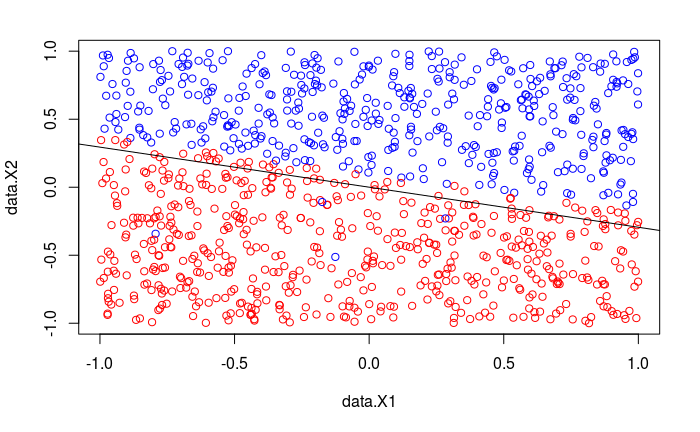

```r
perceptron(data)
```